# cp4

## Os dados

O GitHub é uma plataforma online que se tornou padrão para desenvolvedores armazenarem projetos e repositórios online. Devido a sua facilidade de uso e importância para o ecosistema da comunidade Open Source, existe uma enorme base de usuários que utilizam a plataforma diariamente, bem como uma enorme variedade de projetos que são hospedados. Por essas características, os dados do GitHub se tornam bons indicadores de tendências e hábitos de desenvolvedores e projetos do mundo todo.

A amostra abaixo é um pequeno traço desses dados.

```r
github = read.csv(here::here("data/github-users-committing-filetypes.csv"))
glimpse(github)
```

```
## Observations: 13,802
## Variables: 5
## $ file_extension <fct> md, md, md, md, md, md, md, md, md, md, md, md,...
## $ month_day      <int> 18, 17, 27, 16, 26, 21, 4, 22, 23, 1, 12, 3, 2,...
## $ the_month      <int> 2, 2, 1, 2, 1, 3, 2, 2, 2, 2, 4, 2, 2, 2, 4, 3,...
## $ the_year       <int> 2016, 2016, 2016, 2016, 2016, 2017, 2016, 2016,...
## $ users          <int> 10279, 10208, 10118, 10045, 10020, 10015, 9991,...
```

A .csv contém os dados de commits de 2016 até 2017, além a quantidade de usuários que commitaram arquivos daquela extensão. A extensão implica na linguagem utilizada para escrever o código. Sabemos, contudo, que queremos observar o comportamento desses dados durante dias de semana e finais de semana. Utilizando a biblioteca `lubridate`, conseguimos transformar as datas do *data frame* em dias da semana, de forma que, ao escolhermos as duas linguagens para análise, a manipulação dos dados seja mais prática. Os dias da semana são representados de 1 à 7, representando respectivamente de Domingo à Sábado.

```r
github <- mutate(github, dia_da_semana = wday(ymd(paste(github$the_year,"/",github$the_month,"/",github$month_day))))
github <- mutate(github, eh_fds = ifelse(github$dia_da_semana == 1 | github$dia_da_semana == 7, "Sim", "Não"))
glimpse(github)
```

```
## Observations: 13,802
## Variables: 7
## $ file_extension <fct> md, md, md, md, md, md, md, md, md, md, md, md,...
## $ month_day      <int> 18, 17, 27, 16, 26, 21, 4, 22, 23, 1, 12, 3, 2,...
## $ the_month      <int> 2, 2, 1, 2, 1, 3, 2, 2, 2, 2, 4, 2, 2, 2, 4, 3,...
## $ the_year       <int> 2016, 2016, 2016, 2016, 2016, 2017, 2016, 2016,...
## $ users          <int> 10279, 10208, 10118, 10045, 10020, 10015, 9991,...
## $ dia_da_semana  <dbl> 5, 4, 4, 3, 3, 3, 5, 2, 3, 2, 3, 4, 3, 3, 3, 4,...
## $ eh_fds         <chr> "Não", "Não", "Não", "Não", "Não", "Não", "Não"...
```

Existem diversas extensões, que representam linguagens. Desse universo, filtraremos os dados para analisar somente as linguagem *python* e *shell*.

```r
dados_filtrados <- github %>%
          filter(file_extension == 'py' | file_extension == "sh")
dados_filtrados <- mutate(dados_filtrados, file_extension = ifelse(dados_filtrados$file_extension == "py" , "Python", "Shell"))
```

## Perguntas

> 1 - Para cada uma delas, há uma diferença significativa na sua popularidade durante a semana e durante o fim de semana? Essa diferença é grande? (dica: aqui você precisa decidir como medir popularidade: média? mediana? outra estatística?)

Para responder essa pergunta, defino como critério de popularidade a média de usuários que commitaram durante a semana e o final de semana. Por quê a média? Porque todos os usuários tem valor igual para nossa análise. Queremos analisar uma estatística que é comum a todos, sem peso ou valor maior para um elemento específico.

Assim, temos as seguintes tabelas com a média de usuários que commitaram da amostra para dias de semana e finais de semana

```r
amostra <- dados_filtrados %>%
          select(eh_fds, users, file_extension) %>%
          group_by(eh_fds, file_extension)
```

Para a linguagem *shell*:

[interactive chart not shown]

Podemos ver que os programadores em *shell* preferem subir seu trabalho durante os dias de semana.

```r
mean.fds_sh = amostra_shell %>%
  filter(eh_fds == "Sim") %>%
  bootstrap(mean(users),
            R=2000) %>%
  CI.percentile(probs = c(.025, .975))

mean.semana_sh = amostra_shell %>%
  filter(eh_fds == "Não") %>%
  bootstrap(mean(users),
            R=2000) %>%
  CI.percentile(probs = c(.025, .975))
```

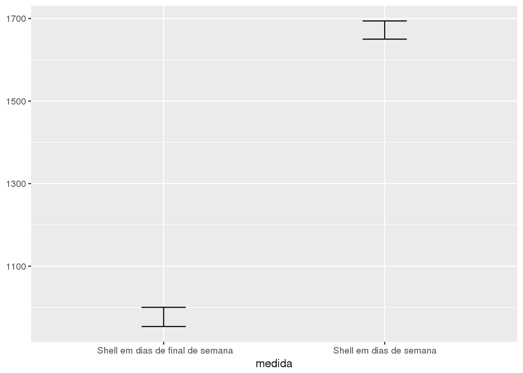

```r
df = data.frame(rbind(mean.fds_sh, mean.semana_sh))

df$medida = c(' Shell em dias de final de semana', 'Shell em dias de semana')

df %>%
  ggplot(aes(x = medida, ymin = X2.5., ymax = X97.5.)) +
  geom_errorbar(width = .2)
```

A diferença é razoável mas não chega a ser tão grande como o da linguagem *python* logo abaixo.

Para a linguagem *python*:

[interactive chart not shown]

```r
mean.fds_py = amostra_python %>%
  filter(eh_fds == "Sim") %>%
  bootstrap(mean(users),
            R=2000) %>%
  CI.percentile(probs = c(.025, .975))

mean.semana_py = amostra_python %>%
  filter(eh_fds == "Não") %>%
  bootstrap(mean(users),
            R=2000) %>%
  CI.percentile(probs = c(.025, .975))
```

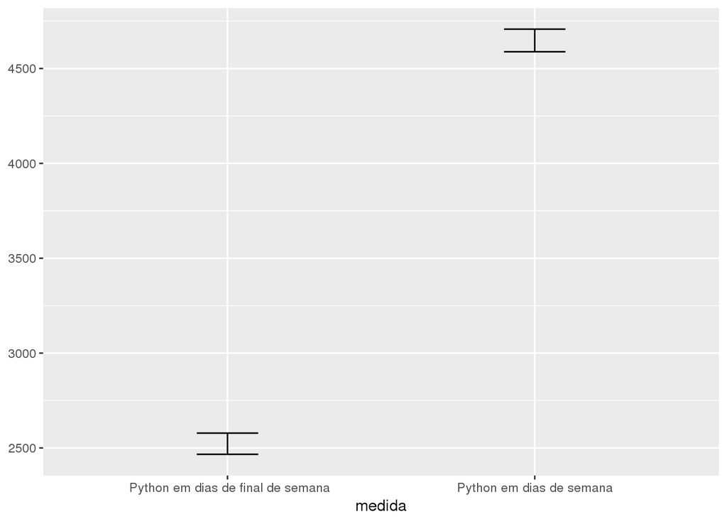

```r
df = data.frame(rbind(mean.fds_py, mean.semana_py))

df$medida = c(' Python em dias de final de semana', 'Python em dias de semana')

df %>%
  ggplot(aes(x = medida, ymin = X2.5., ymax = X97.5.)) +
  geom_errorbar(width = .2)
```

Vemos que existe uma diferença significativa entre a popularidade da linguagem durante a semana e durante o final de semana. É quase o dobro da média de usuários que commitam mais durante a semana.

> 2 - Existe uma diferença significativa entre a popularidade das duas linguagens nos fins de semana? (a mesma dica vale)

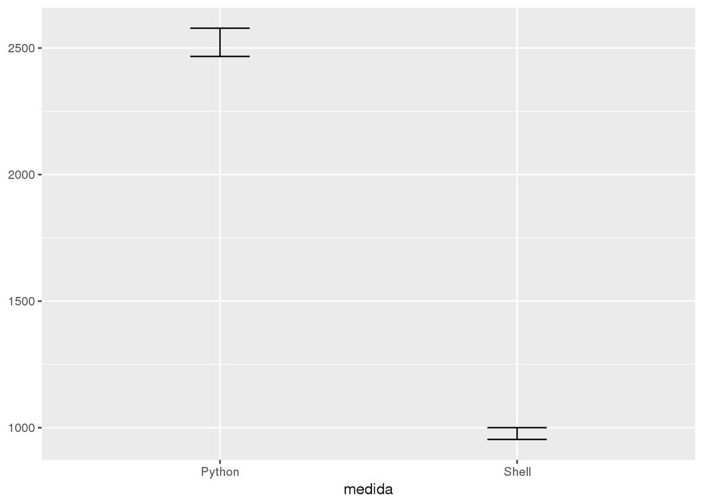

Podemos ver a gritante diferença não-pareada de popularidade entre *shell* e *python* durante os commits de finais de semana. O pessoal prefere passar o free time se divertindo com *python*, claramente.